# ES_Holt_Holts_Winter

```python
series = [3,10,12,13,12,10,12]
```

Simple Average Method

```python
def average(series):
    return float(sum(series))/len(series)

average(series)
```

```
10.285714285714286
```

Moving average:- </br> only the recent values matter </br> sometimes called a “sliding window” of size n

```python
def moving_average(series, n):
    return average(series[-n:])

moving_average(series, 3)
moving_average(series, 4)
```

```
11.75
```

Weighted Moving Average

```python
def weighted_average(series, weights):
    result = 0.0
    weights.reverse()
    for n in range(len(weights)):
        result += series[-n-1] * weights[n]
    return result

weights = [0.1, 0.2, 0.3, 0.4]
weighted_average(series, weights)
```

```
11.500000000000002
```

The weights should sum to 1 to get something meaningful

```python
weights = [0.8, 0.7, 0.6, 0.5]
weighted_average(series, weights)
```

```
30.799999999999997
```

clearly bobus answer

## Single Exponential Smoothing

Imagine a weighted average where we consider all of the data points, while assigning exponentially smaller weights as we go back in time.

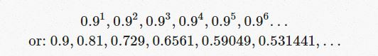

```python
from IPython.display import Image
Image(filename='SES.jpg')
```

If the series is long, the weights will approach to zero

weights do not add up to 1

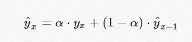

```python
Image(filename='PRH.jpg') # Poison , Robert, Holt
```

expected y = alpha X actual y at the same time step + 1-alpha X value of Y at previous time step

alpha = smoothing factor or smoothing coefficient

```python
def exponential_smoothing(series, alpha):
    result = [series[0]] # first value is same as series
    for n in range(1, len(series)):
        result.append(alpha * series[n] + (1 - alpha) * result[n-1])
    return result

exponential_smoothing(series, 0.1)
```

```
[3, 3.7, 4.53, 5.377, 6.0393, 6.43537, 6.991833]
```

```python
exponential_smoothing(series, 0.9)
```

```
[3, 9.3, 11.73, 12.873000000000001, 12.0873, 10.20873, 11.820873]
```

Expcted value = baseline, intercept, level

This is Simple Exponential Smoothing

## Double Exponential smoothing

```python
## Adding Slope or trend component
```

```python
Image(filename='slope.jpg')
```

[output not shown]

```python
Image(filename='trend.jpg')
```

[output not shown]

b or beta is our trend/slope

Additive vs Multiplicative

we can say that something costs $20 more or 5% more

Practice shows that a ratio (i.e. multiplicative) is a more stable predictor

This is Double Exponential Smoothing or Holts method

So now we have two components to a series: level/baseline/intercept and a trend

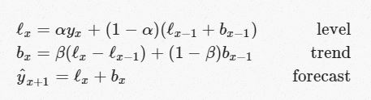

```python
Image(filename='DES.jpg')
```

```python
def double_exponential_smoothing(series, alpha, beta):
    result = [series[0]]
    for n in range(1, len(series)+1):
        if n == 1:
            level, trend = series[0], series[1] - series[0]
        if n >= len(series): # we are forecasting
          value = result[-1]
        else:
          value = series[n]
        last_level, level = level, alpha*value + (1-alpha)*(level+trend)
        trend = beta*(level-last_level) + (1-beta)*trend
        result.append(level+trend)
    return result

double_exponential_smoothing(series, 0.9, 0.8)
```

```
[3,
 17.0,
 15.899999999999999,
 14.602000000000002,
 11.698760000000002,
 8.3853288,
 12.456548944,
 13.274565008]
```

This is Double Exponential Smoothing

## Tripple Exponential smoothing or Holt-Winter Method

If a series appears to be repetitive at regular intervals, such an interval is referred to as a season

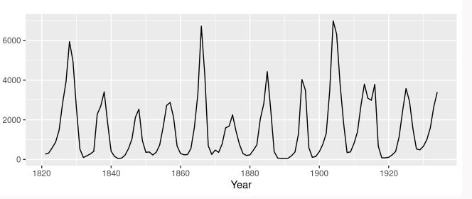

```python
Image(filename='seasonalTS.jpg')
```

Season length is the number of data points after which a new season begins

The seasonal component is an additional deviation from level + trend that repeats itself at the same offset into the season

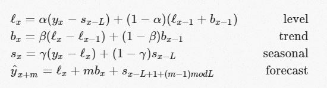

```python
Image(filename='HW.jpg')
```

```python
series = [30,21,29,31,40,48,53,47,37,39,31,29,17,9,20,24,27,35,41,38,
          27,31,27,26,21,13,21,18,33,35,40,36,22,24,21,20,17,14,17,19,
          26,29,40,31,20,24,18,26,17,9,17,21,28,32,46,33,23,28,22,27,
          18,8,17,21,31,34,44,38,31,30,26,32]
```

```python
len(series)
```

```
72
```

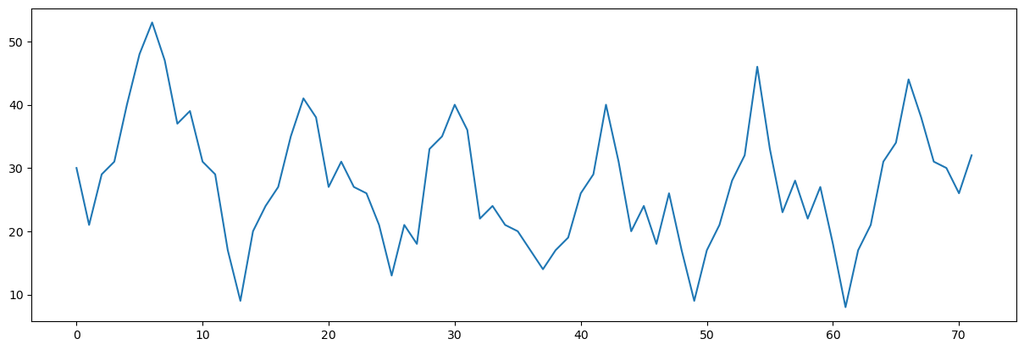

```python
import matplotlib.pyplot as plt
f = plt.figure()
f.set_figwidth(15)
plt.plot(series)
plt.show()
```

```python
def initial_trend(series, slen):
    sum = 0.0
    for i in range(slen):
        sum += float(series[i+slen] - series[i]) / slen
    return sum / slen
initial_trend(series, 12)
```

```
-0.7847222222222222
```

```python
def initial_seasonal_components(series, slen):
    seasonals = {}
    season_averages = []
    n_seasons = int(len(series)/slen)
    # compute season averages
    for j in range(n_seasons):
        season_averages.append(sum(series[slen*j:slen*j+slen])/float(slen))
    # compute initial values
    for i in range(slen):
        sum_of_vals_over_avg = 0.0
        for j in range(n_seasons):
            sum_of_vals_over_avg += series[slen*j+i]-season_averages[j]
        seasonals[i] = sum_of_vals_over_avg/n_seasons
    return seasonals
initial_seasonal_components(series, 12)
```

```
{0: -7.4305555555555545,
 1: -15.097222222222221,
 2: -7.263888888888888,
 3: -5.097222222222222,
 4: 3.402777777777778,
 5: 8.069444444444445,
 6: 16.569444444444446,
 7: 9.736111111111112,
 8: -0.7638888888888887,
 9: 1.902777777777778,
 10: -3.263888888888889,
 11: -0.7638888888888887}
```

```python
def triple_exponential_smoothing(series, slen, alpha, beta, gamma, n_preds):
    result = []
    seasonals = initial_seasonal_components(series, slen)
    for i in range(len(series)+n_preds):
        if i == 0: # initial values
            smooth = series[0]
            trend = initial_trend(series, slen)
            result.append(series[0])
            continue
        if i >= len(series): # we are forecasting
            m = i - len(series) + 1
            result.append((smooth + m*trend) + seasonals[i%slen])
        else:
            val = series[i]
            last_smooth, smooth = smooth, alpha*(val-seasonals[i%slen]) + (1-alpha)*(smooth+trend)
            trend = beta * (smooth-last_smooth) + (1-beta)*trend
            seasonals[i%slen] = gamma*(val-smooth) + (1-gamma)*seasonals[i%slen]
            result.append(smooth+trend+seasonals[i%slen])
    return result
```

```python
series = actual data
slen = seasonal length
alpha = to get the level/baseline/intercept
beta = to get the trend component
gamma = toget the seasonal component
n_preds = forecasting time horizon
```

```python
pred_series = triple_exponential_smoothing(series, 12, 0.7, 0.03, 0.1, 24)
```

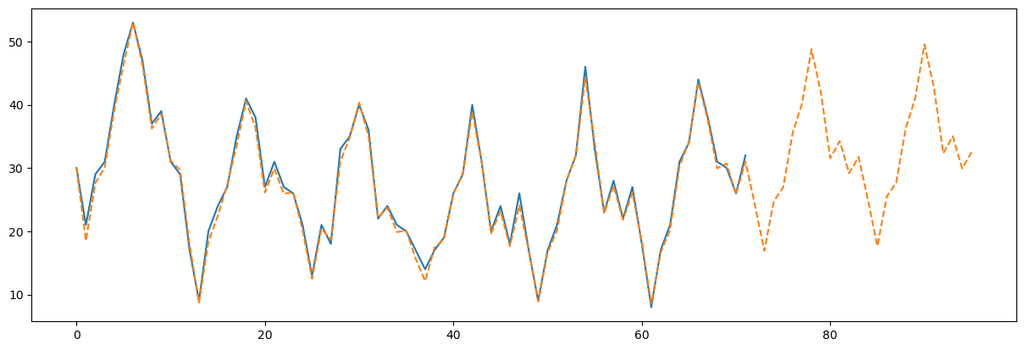

```python
f = plt.figure()
f.set_figwidth(15)
plt.plot(series)
plt.plot(pred_series,linestyle='dashed')
plt.show()
```